# Task 2: Mini exploratory report on juvenile showshoe hares in Bonanza Creek Experimental Forest

By: Claire Gonzales

November 10, 2021

## 2. Data and Analysis

Full metadata can be found at the following URL: https://portal.edirepository.org/nis/metadataviewer?packageid=knb-lter-bnz.55.22

## 3. Initial Juvenile Hare Investigation

### 3a. Annual juvenile hare trap counts

[figure not shown]

**Figure 1.** Number of juvenile snowshoe hares that were captured within the Bonanza Creek Experimental Forest between the years 1999 and 2012. (Data: Kielland et. al., 2017)

### 3b. Juvenile hare weight visualization

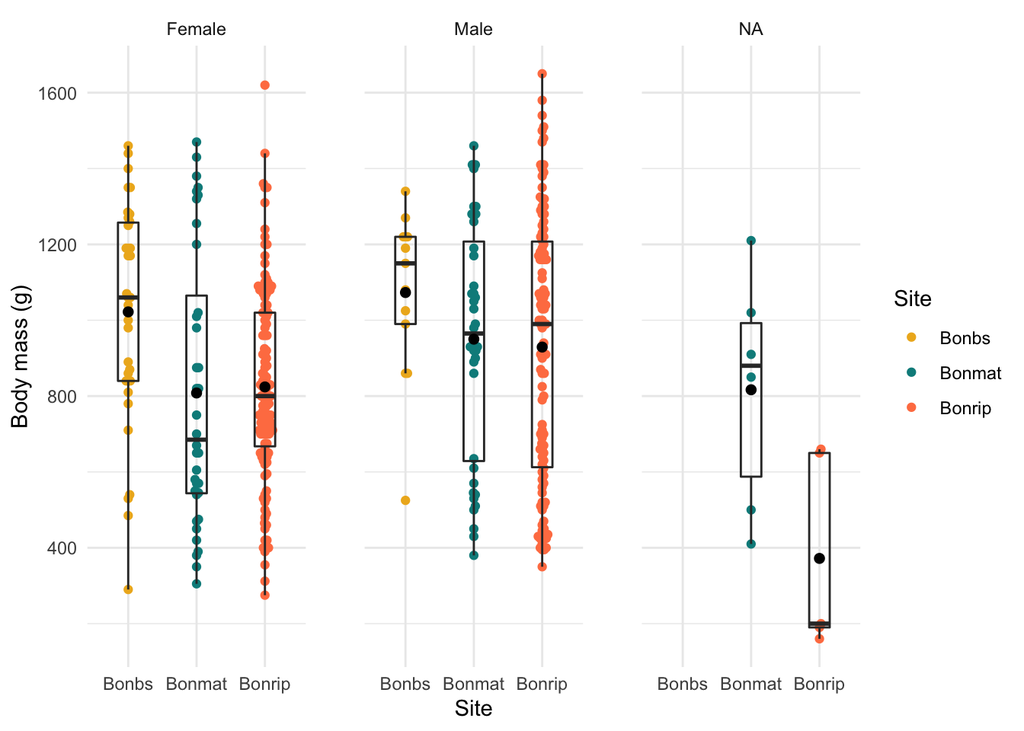

**Figure 2.** Comparisons of body mass values (grams) juvenile snowshoe hares captured at Bonanza Creek Experimental Forest between the years 1999 and 2012. Female snowshoe hares are in left pane, followed by male snowshoe hares (middle pane) and hares for which sex was not collected (right pane). Each pane contains body mass measurements for juvenile snowshoe hares captures at each site (Bonbs, Bonmat, and Bonrip). Capture observations from each site are further described with a box plot. The box’s middle black line represents the median values, while the outsides of the box represent the 25th and 75th percentile values. The black dot represents the mean value of observations. (Data: Kielland et. al., 2017)

The data above (**Figure 2**) reflects that the body mass (g) measurements of male juvenile snowshoe hares had slightly larger mean and median values compared to those measurements made for female juvenile snowshoe hares. In general, these data contain very few outliers, with only one positive outlier for female observations at the Bonrip site and one negative outlier for male observations at the Bonbs site. Notably, the heaviest snowshoe hares for both male and female measurements were captured at the Bonrip site. Conversely, the highest mean and median values were in the Bonbs site across sexes. Few hares could not be sexed and all of those observations (NA; right pane) were constrained to Bonmat and Bonrip sites.

### 3c. Juvenile weight comparison (male & female snowshoe hares)

**Table 1** Shows a summary statistics table for body weight distribution with respect to sex of juvenile snowshoe hares captured in Bonanza Creek Experimental Forest between the years 1999 and 2012. (Data: Kielland et. al., 2017)

| Sex | Mean (g) | Standerd Deviation (g) | Count |
| --- | --- | --- | --- |
| Female | 855.4 | 292.3 | 200 |
| Male | 945.9 | 333.2 | 163 |
| NA | 614.5 | 357.6 | 15 |

### 3d. Relationship between juvenile weight & hind foot length

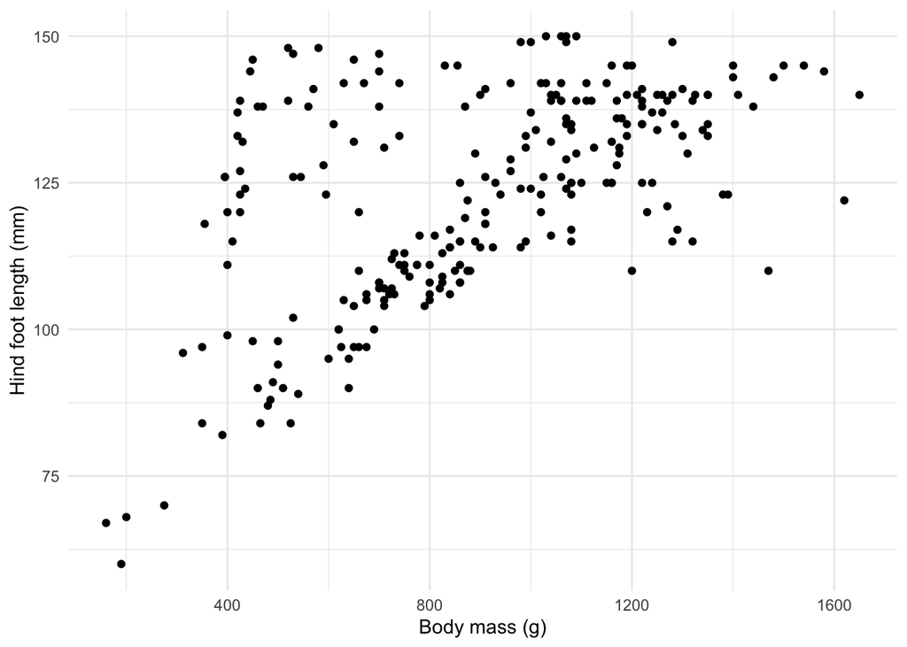

**Figure 3** Visualization of initial relationship between body mass (g) with hind leg length (mm) of juvenile snowshow hares captured in Bonanza Creek Experimental Forest between the years 1999 and 2012. (Data: Kielland et. al., 2017)

The relationship between snowshoe hare body mass (g) and hind foot length (mm) is fairly linear across sex and site (**Figure 3.**). In exploring this more, the simple linear regression reflected that hare body mass loosely predicts length of hind foot (p < 0.001, R<sup>2</sup> = 0.299). If all other factors remain constant, on average we would expect hind foot length to increase by 0.031mm per 1g increase in body mass (slope = 0.031mm/g). Body mass (g) and hind foot length (mm) of juvenile snowshoe hares have medium-positive and significant coorelation (Pearson’s *r* = 0.55, p < 0.001). Lastly, diagnostic plots (not included) revealed normally distributed residuals, but residuals were fairly heteroscedastic. This is a concern in using this linear regression to draw conclusions about the population.

## 4. Summary of Results

This initial exploration of the data reflected the following results:

- The amount of juvenile snowshoe hares captured was highest in the first year of the project (1999) and has decreased over time.
- Male juvenile snowshoe hares weigh more than females do, across all sites and with very few outliers. The difference is significant, but the effect size is small.
- The relationship between body mass and hind foot length of juvenile snowshoe hares is medium-positively and positively correlated. Therefore, if all other factors remain constant, on average we would expect hind foot length to increase by 0.031mm per 1g increase in body mass.

Next steps:

- Standardize data across all years that hares were captured to determine how many hares were captured compared to the amount of attempts made.
- Investigate multiple linear regressions that could describe how body mass and other potential variables (e.g. sex or site) could impact hind foot length.
- Alternately, select more focused variables to remove heteroscedasticity in linear regression model.

## 5. Citations

Kielland, K., F.S. Chapin, R.W. Ruess, and Bonanza Creek LTER. 2017. Snowshoe hare physical data in Bonanza Creek Experimental Forest: 1999-Present ver 22. Environmental Data Initiative. https://doi.org/10.6073/pasta/03dce4856d79b91557d8e6ce2cbcdc14